# Homework10: For Loops and Randomization Tests

Eurydice Aboagye

2023-05-02

### Question One

Using a for loop, write a function to calculate the number of zeroes in a numeric vector. Before entering the loop, set up a counter variable counter <- 0. Inside the loop, add 1 to counter each time you have a zero in the vector. Finally, use return(counter) for the output

```r
zero_counts <- function(x) {
  counter <- 0  # setting up the counter variable

  for (i in x) {
    if (i == 0) {
      counter <- counter + 1  # adding 1 to counter each time there is a zero in the vector
    }
  }

  return(counter)  # Return the final count of zeroes
}


# Testing the function..

d<- c(rep(-1:3, times=5))
print(d)
```

```
##  [1] -1  0  1  2  3 -1  0  1  2  3 -1  0  1  2  3 -1  0  1  2  3 -1  0  1  2  3
```

```r
zero_counts(x=d)
```

```
## [1] 5
```

### Question Two

Use subsetting instead of a loop to rewrite the function as a single line of code.

```r
zero_counter <- function(x){
  return(sum(x==0))# return the sum of elements in x that are equal to zero
}

#  Testing zero counter
zero_counter(x=d)
```

```
## [1] 5
```

### Question Three

Write a function that takes as input two integers representing the number of rows and columns in a matrix. The output is a matrix of these dimensions in which each element is the product of the row number x the column number.

```r
#######################################
# FUNCTION: matrix_builder
# packages: none
# purpose:Building a dummy matrix
# input: two integers, x and y, representing the number of rows and column in a matrix
# output: a matrix of specified dimensions in which each element is the product of the row number x the column number y
# -------------------------------------

matrix_builder <- function(x=NULL, y=NULL) {
  if(is.null(x)) m <- matrix(data = d, nrow = 5, ncol = 5, byrow = TRUE) # setting a null to mostly to check if function works
  else{
  m <- matrix(data=outer(1:x, 1:y, "*"), # found this outer function online. It's output is a matrix that applies a specified function to elements, in this case, a multiplier
                nrow=x,
                ncol=y,
                byrow=FALSE)}
  return(m)
  }

# Testing matrix builder

matrix_builder()
```

```
##      [,1] [,2] [,3] [,4] [,5]
## [1,]   -1    0    1    2    3
## [2,]   -1    0    1    2    3
## [3,]   -1    0    1    2    3
## [4,]   -1    0    1    2    3
## [5,]   -1    0    1    2    3
```

```r
matrix_builder(6,10)
```

```
##      [,1] [,2] [,3] [,4] [,5] [,6] [,7] [,8] [,9] [,10]
## [1,]    1    2    3    4    5    6    7    8    9    10
## [2,]    2    4    6    8   10   12   14   16   18    20
## [3,]    3    6    9   12   15   18   21   24   27    30
## [4,]    4    8   12   16   20   24   28   32   36    40
## [5,]    5   10   15   20   25   30   35   40   45    50
## [6,]    6   12   18   24   30   36   42   48   54    60
```

### Question Four

1. Simulate a dataset with 3 groups of data, each group drawn from a distribution with a different mean. The final data frame should have 1 column for group and 1 column for the response variable.

```r
# create treatment groups
trt_group <- c(rep("Control",4),rep("Treatment1",5), rep("Treatment2",5))

# create response variable
res <- c(runif(4) + 1, runif(5) + 10, runif(5) + 6)
print(res)
```

```
##  [1]  1.625834  1.024042  1.300535  1.983607 10.541051 10.215355 10.560342
##  [8] 10.558259 10.704845  6.630797  6.205721  6.815931  6.575703  6.485375
```

```r
print(trt_group)
```

```
##  [1] "Control"    "Control"    "Control"    "Control"    "Treatment1"
##  [6] "Treatment1" "Treatment1" "Treatment1" "Treatment1" "Treatment2"
## [11] "Treatment2" "Treatment2" "Treatment2" "Treatment2"
```

```r
# combine into a data frame
df<- data.frame(group= trt_group, response=res)
print(df)
```

```
##         group  response
## 1     Control  1.625834
## 2     Control  1.024042
## 3     Control  1.300535
## 4     Control  1.983607
## 5  Treatment1 10.541051
## 6  Treatment1 10.215355
## 7  Treatment1 10.560342
## 8  Treatment1 10.558259
## 9  Treatment1 10.704845
## 10 Treatment2  6.630797
## 11 Treatment2  6.205721
## 12 Treatment2  6.815931
## 13 Treatment2  6.575703
## 14 Treatment2  6.485375
```

2. Write a custom function that 1) reshuffles the response variable, and 2) calculates the mean of each group in the reshuffled data.

```r
remix_var<- function(x){
  .<- data.frame(group=x[,1], response=sample(x[,2]))
  df1<- aggregate(.[,2], list(.[,1]), FUN=mean)
  return(df1)
}

#testing remix_var

remix_var(x=df)
```

```
##      Group.1        x
## 1    Control 7.465736
## 2 Treatment1 6.894664
## 3 Treatment2 5.378226
```

3. Use a for loop to repeat the function in b 100 times. Store the results in a data frame that has 1 column indicating the replicate number and 1 column for each new group mean, for a total of 4 columns.

```r
# creating an empty dataframe to hold final output

loopdf<- data.frame(RepNumber=1:100, ControlMeans= rep(NA, 100), T1Means= rep(NA, 100), T2Means= rep(NA, 100))

head(loopdf)
```

```
##   RepNumber ControlMeans T1Means T2Means
## 1         1           NA      NA      NA
## 2         2           NA      NA      NA
## 3         3           NA      NA      NA
## 4         4           NA      NA      NA
## 5         5           NA      NA      NA
## 6         6           NA      NA      NA
```

```r
s<-seq(1:100) # created variable to hold number of times to carry out loo operation

for(i in seq_along(s)){
  . <- remix_var(x=df)
  .<- list(ControlMeans=.[1,2],
           T1Means=.[2,2],
           T2Means=.[3,2])
  loopdf[i,2:4]<- unlist(.) #unlist and coy into last 3 columns of empty data frame
}

print(loopdf)
```

```
##     RepNumber ControlMeans  T1Means   T2Means
## 1           1     8.089499 5.332342  6.441538
## 2           2     7.244309 6.147551  6.302482
## 3           3     7.240735 7.136379  5.316512
## 4           4     5.200145 6.235931  7.849432
## 5           5     7.001365 6.483775  6.160612
## 6           6     4.864635 7.185092  7.168680
## 7           7     6.497440 7.786740  5.260788
## 8           8     7.107113 6.302482  6.257307
## 9           9     6.241379 7.339104  5.913272
## 10         10     6.322079 5.198329  7.989488
## 11         11     7.384312 7.298768  5.039261
## 12         12     7.455603 6.099741  6.181256
## 13         13     6.105226 5.446807  7.914492
## 14         14     4.920291 5.439098  8.870150
```

[output cut: 86 more lines]

4. Use qplot() to create a histogram of the means for each reshuffled group.

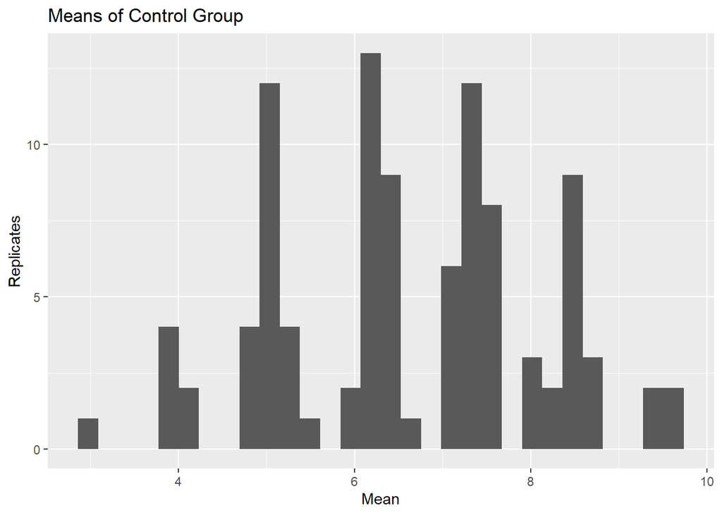

```r
library(ggplot2)
qplot(x=loopdf$ControlMeans, geom = "histogram", xlab = "Mean", ylab = "Replicates", main = "Means of Control Group")
```

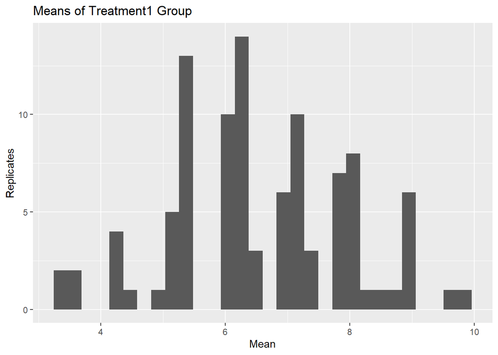

```r
qplot(x=loopdf$T1Means, geom = "histogram", xlab = "Mean", ylab = "Replicates", main = "Means of Treatment1 Group")
```

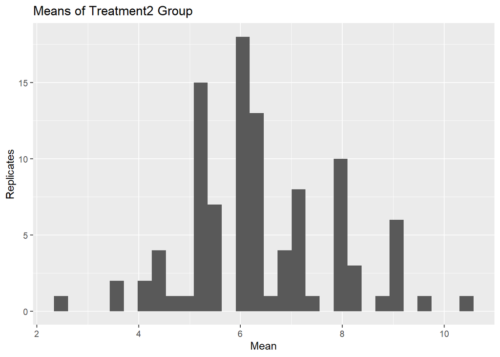

```r
qplot(x=loopdf$T2Means, geom = "histogram", xlab = "Mean", ylab = "Replicates", main = "Means of Treatment2 Group")
```